# Deliverable 1 — Estatística Multivariada

Ricardo_MADA

2026-10-02

# 1. Base de Dados e Legendas das Variáveis

O projeto utiliza quatro bases de dados originadas dos sistemas corporativos, cada uma com uma finalidade específica:

employees.csv (Base de Colaboradores): Contém os dados demográficos e hierárquicos. Variáveis: `employee_id` (Chave identificadora), `seniority` (Nível hierárquico), `department_id` (Setor). training_records.csv (Base de Treinamentos): Histórico de capacitação em Inteligência Artificial. Variáveis: `completion_status` (Status do curso, onde “Concluido” indica sucesso). ai_usage_logs.csv (Base de Consumo): Registros transacionais de uso das ferramentas de IA. Variáveis: `input_tokens` (Volume de texto enviado), `output_tokens` (Volume de texto recebido), `request_count` (Número de interações). security_events.csv (Base de Segurança): Log de incidentes e violações de diretrizes. Variáveis: `event_id` (Identificador do incidente).

# 2. Relação Entre as Bases

As bases seguem uma lógica de modelagem dimensional. O arquivo `employees` atua como a Dimensão principal (Dim_Colaborador), enquanto as outras três bases funcionam como tabelas Fato transacionais.

O relacionamento entre todas elas é feito através da chave primária/estrangeira `employee_id` em um modelo Star Schema. Para a análise estatística, as tabelas Fato são agregadas e unidas à Dimensão via cruzamento direto (`merge`), formando uma única Tabela Analítica (ABT).

# 3. Preparação dos Dados (ETL) e Tratamento de Valores Ausentes

Nesta etapa, os dados transacionais são agrupados por colaborador e unidos à base principal utilizando funções nativas do R para estruturar o código passo a passo.

### Identificação e Tratamento de Nulos

Ao cruzar as bases, colaboradores que não fizeram cursos ou não tiveram incidentes recebem o valor vazio

Contagem de Valores Nulos (Antes do Tratamento)

|  | Variavel | Nulos |
| --- | --- | --- |
| employee_id | employee_id | 0 |
| company_id | company_id | 0 |
| department_id | department_id | 0 |
| job_role | job_role | 0 |
| seniority | seniority | 0 |
| hire_date | hire_date | 0 |
| cost_center | cost_center | 0 |
| active | active | 0 |
| cursos_concluidos | cursos_concluidos | 1611 |
| total_tokens | total_tokens | 1298 |
| total_requests | total_requests | 1298 |
| incidentes_seguranca | incidentes_seguranca | 2289 |

Para a modelagem, esses nulos são convertidos estatisticamente para zero.

# 4. Análise Exploratória e Indicadores Organizacionais

## 4.1. Tabelas de Estatísticas Descritivas

Estatísticas Descritivas dos Indicadores Organizacionais

| Indicador | Min | Media | Max | DP |
| --- | --- | --- | --- | --- |
| Cursos Concluídos | 0 | 0.39 | 3 | 0.63 |
| Total Tokens | 0 | 2700730.06 | 91540959 | 5991975.22 |
| Total Requests | 0 | 114.40 | 863 | 195.78 |
| Incidentes | 0 | 0.03 | 2 | 0.17 |

## 4.2. Distribuição do Consumo de Tokens

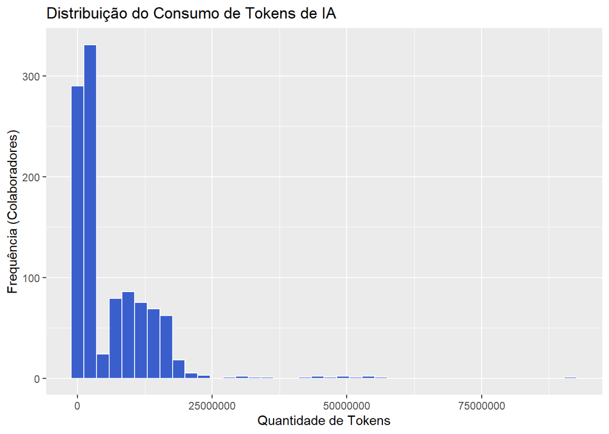

## 4.3. Mapa de Correlação dos Indicadores

Para investigar se o aumento em um indicador organizacional afeta o outro, utilizamos a matriz de correlação linear construída nativamente com o pacote ggplot2.

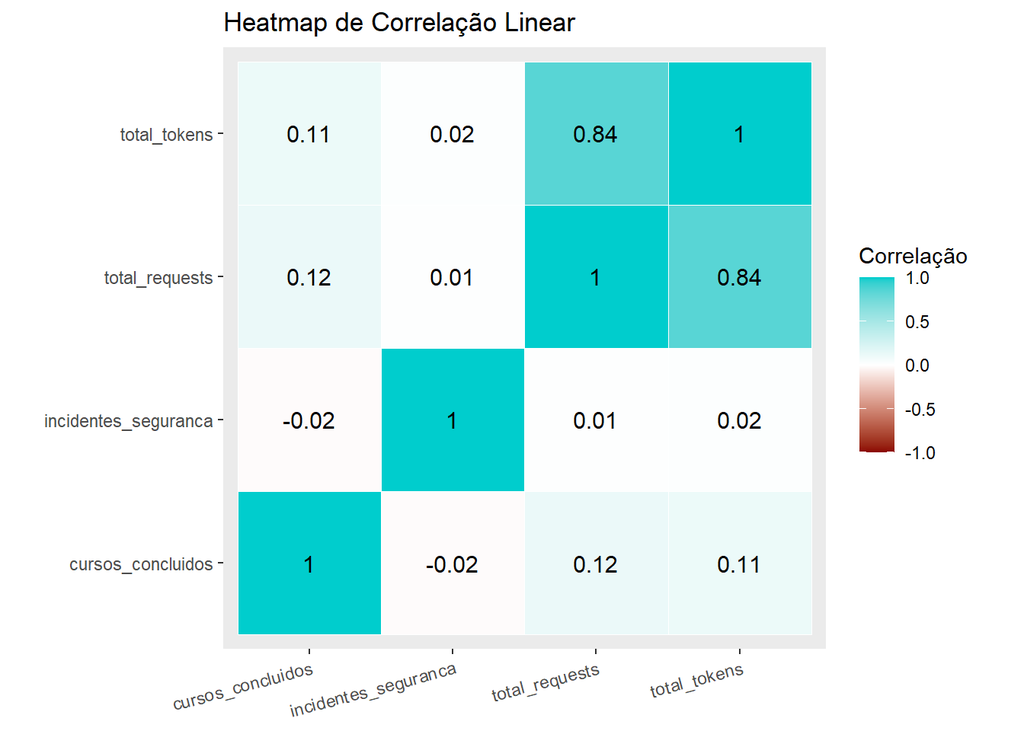

## 4.4. Boxplots: Testando as Hipóteses de Treinamento

A matriz de correlação sugere duas hipóteses de negócio a serem exploradas visualmente: (H1) colaboradores que concluíram treinamentos em IA consomem mais tokens e (H2) colaboradores treinados apresentam menos incidentes de segurança (efeito do treinamento pra proteção). Para investigar essas hipóteses, os colaboradores foram segmentados em dois grupos.

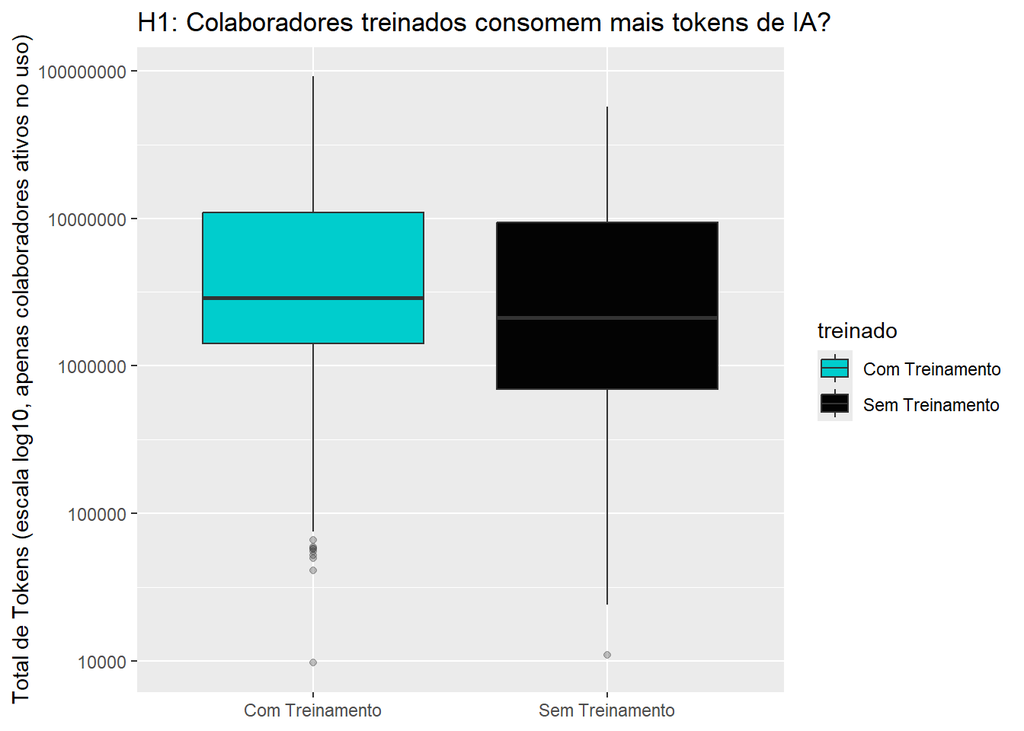

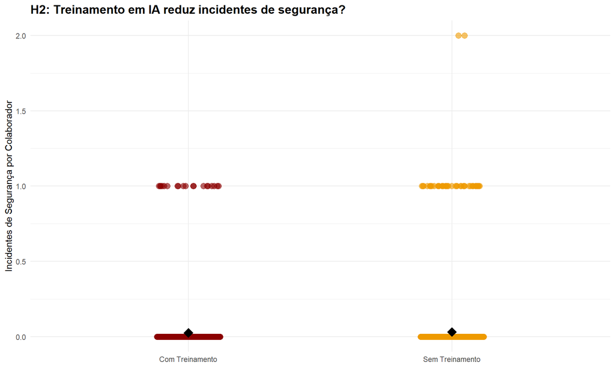

# 5. Conclusão

A preparação dos dados juntou de quatro bases transacionais e dimensionais para uma única matriz analítica granularizada por colaborador (N = 2356), com tratamento adequado de nulos estruturais que preservou a integridade das 2356 observações.

H2 — Treinamento reduz incidentes de segurança: não confirmada pelos dados disponíveis. Os boxplots e as médias por grupo (0.0255 incidentes/colaborador entre treinados vs. 0.031 entre não treinados) são praticamente indistinguíveis, e a correlação entre cursos concluídos e incidentes é essencialmente nula (r = -0.02). Isso é reforçado pela baixíssima incidência do evento na base: apenas 2.8% dos colaboradores registraram algum incidente, tornando qualquer associação estatisticamente frágil com o volume atual de dados. Conclui-se que, com a granularidade e o período disponíveis, não há evidência de um efeito protetor direto do treinamento sobre a segurança — a hipótese de senso comum não se sustenta e não deve ser usada para justificar decisões de política de treinamento sem uma análise multivariada mais robusta (controlando por área, cargo e exposição às ferramentas de IA).